# Project Final Submission Template

### Step 1a: Planning

#### Identify the information in the file your program will read

Describe (all) the information that is available. Be sure to note any surprising or unusual features. (For example, some information sources have missing data, which may be blank or flagged using values like -99, NaN, or something else.)

Age: A float value representing an adult patient's age [18.0, ...). Sex: The sex of a patient, either male or female. BMI: A float value representing a patient's BMI Smoker: Whether or not a patient is a smoker, either yes or no. Region: The region in which a patient lives; northwest, northeast, southwest, or southeast. Children: An integer value representing the amount of children a patient has. Charges: A float value representing the cost of the medical bill of a patient.

No missing data or additional features.

### Step 1b: Planning

#### Brainstorm ideas for what your program will produce

#### Select the idea you will build on for subsequent steps

You must brainstorm at least three ideas for graphs or charts that your program could produce and choose the one that you'd like to work on. You can choose between a line chart, histogram, bar chart, scatterplot, or pie chart.

If you would like to change your project idea from what was described in the proposal, you will need to get permission from your project TA. This is intended to help ensure that your new project idea will meet the requirements of the project. Please see the project proposal for things to be aware of when communicating with your project TA.

Chosen idea: A bar graph to show average Life Quality Risk Index (LQRI) of females in comparison to males, with an x-axis of sex (females and males), and a y-axis of average Life Quality Risk Index (LQRI). The LQRI of an individual will be (age)+ 2(bmi) + 15 if smoker. There will be 2 bars, one representing males and the other representing females, which will be different colours to show a clear distinction between the two.

Second idea: A scatter plot comparing a patient's age to their Life Quality Risk Index ((age)+ 2(bmi) + 15 if smoker). The y-axis would be LQRI, whilst the x-axis is age of patient.

Third idea: A bar graph showing the average LQRI of each region (1 bar per region, so 4 bars in total). The x-axis would be the region, whilst the y-axis is average LQRI.

### Step 1c: Planning

#### Write or draw examples of what your program will produce

You must include an image that shows what your chart or plot will look like. You can insert an image using the Insert Image command near the bottom of the Edit menu.

Insert your image in this cell. Feel free to remove this prompt from this cell.

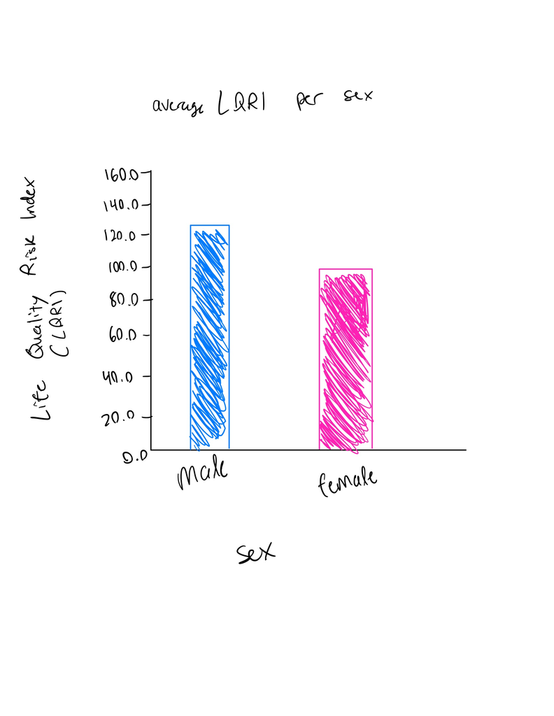

### Step 2a: Building

#### Document which information you will represent in your data definitions

Before you design data definitions in the code cell below, you must explicitly document here which information in the file you chose to represent and why that information is crucial to the chart or graph that you'll produce when you complete step 2c.

In medical_insurance_data.csv, we are only interested in the age, sex, bmi, and smoker columns. Age, bmi, and smoker data will be used to calculate the LQRI of a patient, using the formula (age)+ 2(bmi) + 15 if smoker. Sex data will be used when we calculate the average LQRI for each sex for our bar graph, where there are 2 bars, one for each sex.

#### Design data definitions

```python
from cs103 import *
import csv
from typing import NamedTuple, List
from enum import Enum
import matplotlib.pyplot as pyplot

##################
# Data Definitions


Sex = Enum("sex", ["MALE", "FEMALE"])
#interp. sex of the patient, male or female.

#examples redundant for enumeration

#template based on enumeration (2 cases)
@typecheck
def fn_for_sex(sx:Sex) -> ...:
    if sx == Sex.MALE:
        return ...
    elif sx == Sex.FEMALE:
        return ...


Smoker = Enum("smoker", ["YES", "NO"])
#interp. whether or not the user is a smoker, either yes or no

#examples redundant for enumeration

#template based on enumeration (2 cases)
@typecheck
def fn_for_smoker(sm:Smoker) -> ...:
    if sm == Smoker.YES:
        return ...
    elif sm == Smoker.NO:
        return ...


PatientData = NamedTuple("PatientData", [("age", float), #in range [18.0, ...]
                                         ("sex", Sex),
                                         ("bmi", float), #in range [15.0, 55.0]
                                         ("smoker", Smoker)])
#interp. Information for each patient containing Age, Sex, Bmi, Smoker data.

PD0 = PatientData(18.0, Sex.MALE, 33.50, Smoker.YES)
PD1 = PatientData(22.4, Sex.FEMALE, 50.00000, Smoker.NO)
PD2 = PatientData(44.100000, Sex.MALE, 23.6666, Smoker.YES)
PD3 = PatientData(66.771, Sex.FEMALE, 45.1, Smoker.YES)


# template based on Compound (4 fields) and reference rule
@typecheck
def fn_for_patient_data(pd: PatientData) -> ...:
    return ...(pd.age, fn_for_sex(pd.sex), pd.bmi, fn_for_smoker(pd.smoker))


LOPD0 = []
LOPD1 = [PD0]
LOPD2 = [PD0, PD1]
LOPD3 = [PD0, PD1, PD2]
LOPD4 = [PD0, PD1, PD2, PD3]

#template based on arbitrary sized and reference rule
@typecheck
def fn_for_lopd(lopd: List[PatientData])->...:
    #description of accumulator
    acc = ... #type ...
    for pd in lopd:
        acc = ...(fn_for_patient_data(pd), acc)
    return ...(acc)
```

### Step 2b and 2c: Building

#### Design a function to read the information and store it as data in your program

#### Design functions to analyze the data

Complete these steps in the code cell below. You will likely want to rename the analyze function so that the function name describes what your analysis function does.

Unless approved by your project TA, you **cannot** use libraries such as `numpy` or `pandas`. The project is meant as a way for you to demonstrate your knowledge of the learning goals in this course. While it is convinent to use external libraries, it will do all the work and will not help us gauge your mastery of the concepts.

You also cannot use built in list functions (e.g., `sum` or `average`) when writing code to do your substantial computation. Normally we encourage you to make use of what is already available but in this case, the final project involves demonstrating skills from class (e.g., how to work with a list). Using pre-built functions for this does not enable you to demonstrate what you know.

If you wish to change your project idea, you must **first** obtain permission from your TA. When contacting your TA, please provide a valid reason for why you want to change your project. Each time you change your topic idea, your TA will have to evaluate it to see if it will meet all of the project requirements. This is non-trivial task during one of the busiest times of the semester. As such, the deadline for project idea changes will be 3 business days before the deadline. Note that the deliverable deadline will not be extended and there is no compensation for the time you spent on the previous idea.

```python
###########
# Functions

# Functions for read
@typecheck
def parse_sex(s:str) -> Sex:
    """
    Returns the string s as a Sex
    Assumes sex is either "male" or "female"
    """
    #return Sex.MALE
    #template from atomic non-distinct
    #return ... (s)
    if s == "male":
        return Sex.MALE
    elif s == "female":
        return Sex.FEMALE

start_testing()

expect (parse_sex ("male"), Sex.MALE)
expect (parse_sex ("female"), Sex.FEMALE)

summary()

@typecheck
def parse_smoker(s:str) -> Smoker:
    """
    Returns the string s as a Smoker status
    Assumes smoker is either "yes" or "no"
    """
    #return Smoker.YES
    #template from atomic non-distinct
    #return ... (s)
    if s == "yes":
        return Smoker.YES
    elif s == "no":
        return Smoker.NO

start_testing()

expect (parse_smoker ("yes"), Smoker.YES)
expect (parse_smoker ("no"), Smoker.NO)

summary()


@typecheck
def read(filename: str) -> List[PatientData]:
    """
    reads information from the specified file and returns a list of patient data.
    """
    #return []  #stub
    # Template from HtDAP
    # lopd contains the result so far
    lopd = [] # type: List[PatientData]

    with open(filename) as csvfile:

        reader = csv.reader(csvfile)
        next(reader) # skip header line

        for row in reader:
            # you may not need to store all the rows, and you may need
            # to convert some of the strings to other types
            pd = PatientData(parse_float(row[0]),
                             parse_sex(row[1]),
                             parse_float(row[2]),
                             parse_smoker(row[3]))
            lopd.append(pd)

    return lopd

@typecheck
def is_smoker(pd: PatientData)-> bool:
    """
    returns True if the patient is a smoker, False otherwise
    """
    #return True #stub
    #template from PatientData
    return pd.smoker == Smoker.YES

start_testing()
expect(is_smoker(PD0), True)
expect(is_smoker(PD1), False)
expect(is_smoker(PD2), True)
expect(is_smoker(PD3), True)
summary()

@typecheck
def is_male(pd:PatientData)-> bool:
    """
    returns True if patient is male, False otherwise
    """
    #return True #stub
    #template from PatientData
    return pd.sex == Sex.MALE

start_testing()
expect(is_male(PD0), True)
expect(is_male(PD1), False)
expect(is_male(PD2), True)
expect(is_male(PD3), False)
summary()

@typecheck
def filter_male(lopd: List[PatientData])-> List[PatientData]:
    """
    takes a list of patient data and returns a list of patient data of only males
    """
    #return [] #stub
    #template based on arbitrary sized and reference rule
    #accumulator contains males seen so far
    male_patients = [] #type: List[PatientData]
    for pd in lopd:
        if is_male(pd):
            male_patients.append(pd)
    return male_patients

start_testing()
expect(filter_male(LOPD0), [])
expect(filter_male(LOPD1), [PD0])
expect(filter_male(LOPD2), [PD0])
expect(filter_male(LOPD3), [PD0, PD2])
expect(filter_male(LOPD4), [PD0, PD2])
summary()

@typecheck
def filter_female(lopd: List[PatientData])-> List[PatientData]:
    """
    takes a list of patient data and returns a list of patient data of only females
    """
    #return [] #stub
    #template based on arbitrary sized and reference rule
    #accumulator contains males seen so far
    female_patients = [] #type: List[PatientData]
    for pd in lopd:
        if not is_male(pd):
            female_patients.append(pd)
    return female_patients

start_testing()
expect(filter_female(LOPD0), [])
expect(filter_female(LOPD1), [])
expect(filter_female(LOPD2), [PD1])
expect(filter_female(LOPD3), [PD1])
expect(filter_female(LOPD4), [PD1,PD3])
summary()

@typecheck
def is_invalid_patient(pd:PatientData) -> bool:
    """
    Determines whether or not a patient has invalid data. Invalid data is defined as any patient with missing data in any of one of age, sex, bmi, or smoker.
    Returns True if patient has invalid data.
    Returns False otherwise.
    """
    # return True #stub
    # template based on PatientData
    if pd.age is None or pd.sex is None or pd.bmi is None or pd.smoker is None:
        return True
    else:
        return False

start_testing()
expect(is_invalid_patient(PatientData(18.0,Sex.MALE, 33.50, Smoker.YES)), False )
expect(is_invalid_patient(PatientData(None, Sex.MALE, 33.50, Smoker.YES)), True )
expect(is_invalid_patient(PatientData(18.0, None, 33.50, Smoker.YES)), True )
expect(is_invalid_patient(PatientData(18.0,Sex.MALE, None, Smoker.YES)), True )
expect(is_invalid_patient(PatientData(18.0,Sex.MALE, 33.50, None)), True )
summary()

@typecheck
def calculate_lqri(pd: PatientData) -> float:
    """
    Takes data of patients and calculates the life quality risk index (LQRI)
    defined as age + 2*(bmi) + 15 if smoker. The higher the lQRI, the higher health risk
    imposed on the patient.
    If any of the data is missing or invalid for patient data, patient's LQRI is deemed to be 100.0 due to it being around the average
    of all patients, thus it won't affect future average LQRI calculations.
    """
    #return [] #stub
    #template based on PatientData
    if is_invalid_patient(pd):
        return 100.0
    elif is_smoker(pd):
        return ((2*pd.bmi) + pd.age + 15)
    else:
        return ((2*pd.bmi) + pd.age)


start_testing()
expect(calculate_lqri(PD0), 100.0 )
expect(calculate_lqri(PD1), 122.4)
expect(calculate_lqri(PD2), 106.4332)
expect(calculate_lqri(PD3), 171.971)
summary()

@typecheck
def list_lqri(lopd: List[PatientData]) -> List[float]:
    """
    takes a list of patient data and returns a list of the life quality risk index values
    as a list of every male patient
    """
    #return [] #stub
    #template based on arbitrary sized and reference rule
    #accumulator contains life quality risk index of male patients seen so far
    list_lqri = [] #type List[PatientData]
    for pd in lopd:
        list_lqri.append(calculate_lqri(pd))
    return list_lqri
```

```python
start_testing()
expect(list_lqri(LOPD0), [])
expect(list_lqri(LOPD1), [100.0])
expect(list_lqri(LOPD2), [100.0, 122.4])
expect(list_lqri(LOPD3), [100.0, 122.4, 106.4332])
expect(list_lqri(LOPD4), [100.0, 122.4, 106.4332, 171.971])
summary()




@typecheck
def length(lof: List[float]) -> int:
    """
    Takes a list of floats and returns the number of how many floats
    are in the list
    """
    #return 5 #stub
    #template based on arbitrary sized
    #accumulator contains the amount of floats seen so far in lof
    count = 0 #type: List[float]
    for f in lof:
        count = count + 1
    return count

start_testing()
expect(length([]), 0)
expect(length([100.0]), 1)
expect(length([100.0, 122.4]), 2)
expect(length([100.0, 122.4, 53.2166]), 3)
expect(length([100.0, 122.4, 53.2166, 53.2166]), 4)
summary()

@typecheck
def sum_float(lof:List[float]) -> float:
    """
    Takes a list of floats and returns the sum of
    all floats in in that list
    """
    #return 70000.0 #stub
    #template based on arbitrary sized
    #accumulator contains the sum of floats seen so far in lof
    sum_float = 0.0 #type: List[float]
    for f in lof:
        sum_float = sum_float + f
    return sum_float

start_testing()
expect(sum_float([]), 0.0)
expect(sum_float([100.0]), 100.0)
expect(sum_float([100.0, 122.4]), 222.4)
expect(sum_float([100.0, 122.4, 53.2166, 53.2166]), 328.8332)
expect(sum_float([100.0, 122.4, 53.2166, 53.2166, 171.971]), 500.8042)
summary()


@typecheck
def average_float(lof: List[float])-> float:
    """
    Takes a list of floats and returns the average float value
    defined as the sum of floats divided by the sum of floats in the list. If length
    of list sums to 0, function returns 0.0 because dividing by 0 is undefined.
    """
    #return 100.0 #stub
    #template based on optional
    if length(lof) == 0:
        return 0.0
    else:
        return sum_float(lof)/length(lof)

start_testing()
expect(average_float([]), 0.0)
expect(average_float([100.0]), 100.0)
expect(average_float([100.0, 122.4]), 111.2)
expect(average_float([100.0, 122.4, 53.2166, 53.2166]), 82.2083)
expect(average_float([100.0, 122.4, 53.2166, 53.2166, 171.971]), 100.16084)
summary()

@typecheck
def analyze_male(lopd: List[PatientData]) -> float:
    """
    Returns the average LQRI for males in lopd.
    """
    #return 0.0 #stub
    # template based on Composition
    # Step 1: filter list of patient data for male patients only, store in male_only
    # Step 2: calculate lqri for each male patient in male_only, store in list_male_lqri
    # Step 3: calculate average LQRI of all males from list_male_lqri, store in avg_male_lqri
    # Step 4: return average LQRI for males from avg_male_lqri

    male_only = filter_male(lopd) # Step 1
    list_male_lqri = list_lqri(male_only) # Step 2
    avg_male_lqri = average_float(list_male_lqri) # Step 3
    return avg_male_lqri # Step 4

start_testing()
expect(analyze_male(LOPD0), 0.0)
expect(analyze_male(LOPD1), 100.0)
expect(analyze_male(LOPD2), 100.0)
expect(analyze_male(LOPD3), 103.2166)
expect(analyze_male(LOPD4), 103.2166)
summary()

def analyze_female(lopd: List[PatientData]) -> float:
    """
    Returns the average LQRI for females in lopd.
    """
    #return 0.0 #stub
    # template based on Composition
    # Step 1: filter list of patient data for female patients only, store in female_only
    # Step 2: calculate lqri for each female patient in female_only, store in list_female_lqri
    # Step 3: calculate average LQRI of all females from list_female_lqri, store in avg_female_lqri
    # Step 4: return average LQRI for females from avg_female_lqri

    female_only = filter_female(lopd) # Step 1
    list_female_lqri = list_lqri(female_only) # Step 2
    avg_female_lqri = average_float(list_female_lqri) # Step 3
    return avg_female_lqri # Step 4

start_testing()
expect(analyze_female(LOPD0), 0.0)
expect(analyze_female(LOPD1), 0.0)
expect(analyze_female(LOPD2), 122.4)
expect(analyze_female(LOPD3), 122.4)
expect(analyze_female(LOPD4), 147.1855)
summary()

def analyze(lopd:List[PatientData]) -> None:
    """
    Plots the bar graph for average lqri of male patients versus female patients.
    """
    # return None #stub
    # Template based on visualization

    #set x-axis label, y-axis label, and plot title
    pyplot.xlabel('Sex')
    pyplot.ylabel('Average LQRI')
    pyplot.title('Average LQRI of Male and Female Patients')

    # data for bar graph
    x_vals = ['Male', 'Female']
    y_vals = [analyze_male(lopd), analyze_female(lopd)]
    #plot data on bar graph with different colours for each bar
    pyplot.bar(x_vals,y_vals, color=['blue', 'pink'])
    pyplot.show()


@typecheck
def main(filename: str) -> None:
    """
    Reads the file from given filename, analyzes the data, returns the result
    """
    # return 0.0
    # Template from HtDAP, based on function composition
    return analyze(read(filename))


#parsed tested data

#from 'testfile_empty.csv'
TEST_EMPTY = []

#from 'testfile_all_zero.csv'
TEST_ALL_ZERO = [PatientData(0.0, Sex.MALE, 0.0, Smoker.NO),
                 PatientData(0.0, Sex.FEMALE, 0.0, Smoker.YES),
                 PatientData(0.0, Sex.MALE, 0.0, Smoker.NO)]

#from 'testfile_all_MALE.csv'
TEST_ALL_MALE = [PatientData(18.0, Sex.MALE, 40.0, Smoker.YES),
                 PatientData(25.0, Sex.MALE, 30.0, Smoker.NO),
                 PatientData(50.0, Sex.MALE, 20.0, Smoker.YES)]

#from 'testfile_all_FEMALE.csv'
TEST_ALL_FEMALE = [PatientData(18.0, Sex.FEMALE, 40.0, Smoker.YES),
                   PatientData(25.0, Sex.FEMALE, 30.0, Smoker.NO),
                   PatientData(50.0, Sex.FEMALE, 20.0, Smoker.YES)]

#from 'testfile_all_YES_smoker.csv'
TEST_ALL_YES_SMOKER = [PatientData(18.0, Sex.MALE, 40.0, Smoker.YES),
                       PatientData(25.0, Sex.FEMALE, 30.0, Smoker.YES),
                       PatientData(50.0, Sex.MALE, 20.0, Smoker.YES)]

#from 'testfile_all_NO_smoker.csv'
TEST_ALL_NO_SMOKER = [PatientData(18.0, Sex.MALE, 40.0, Smoker.NO),
                      PatientData(25.0, Sex.FEMALE, 30.0, Smoker.NO),
                      PatientData(50.0, Sex.MALE, 20.0, Smoker.NO)]
```

[output not shown]

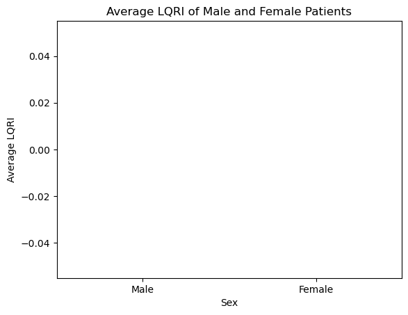

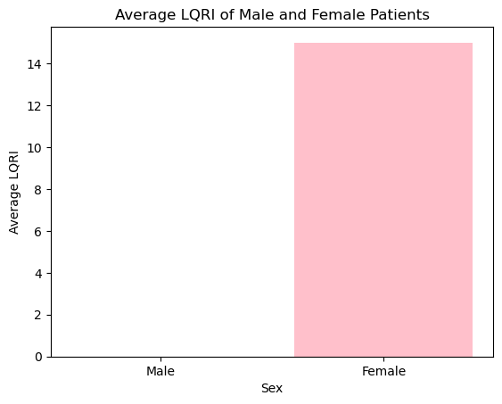

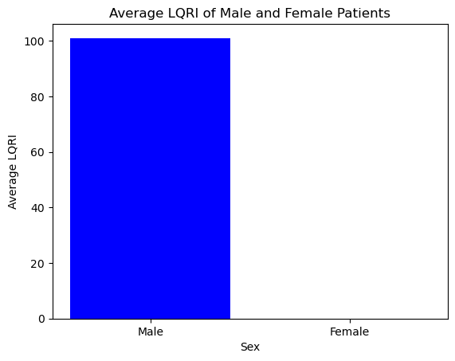

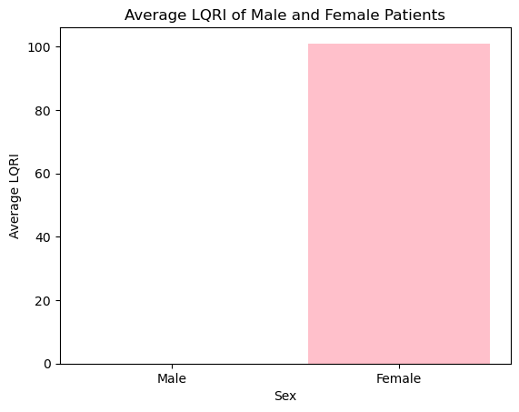

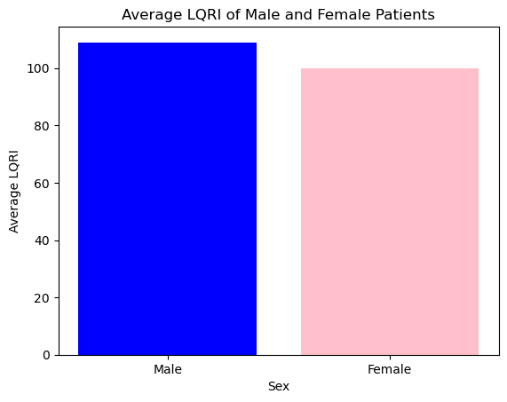

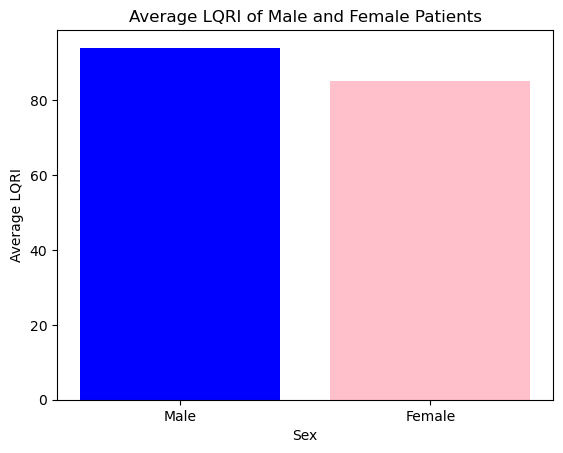

```
6 of 6 tests passed
6 of 6 tests passed
```

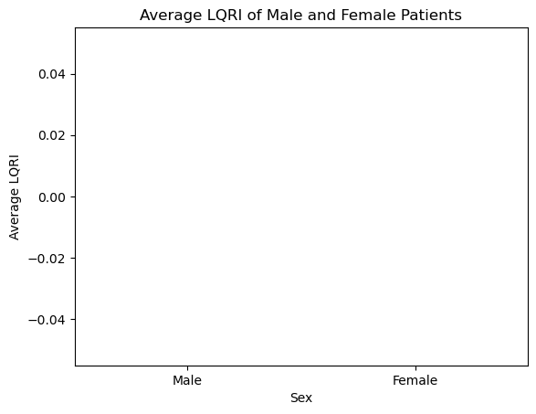

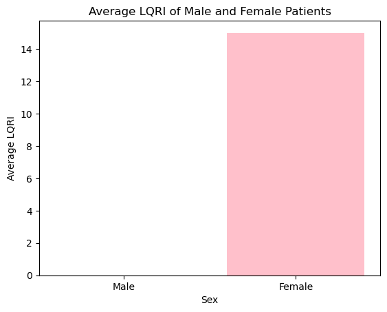

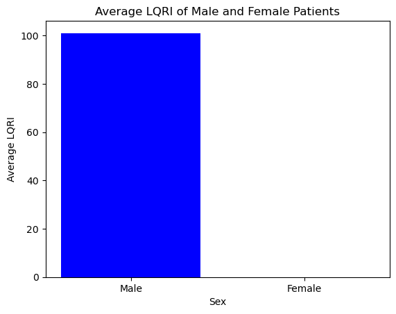

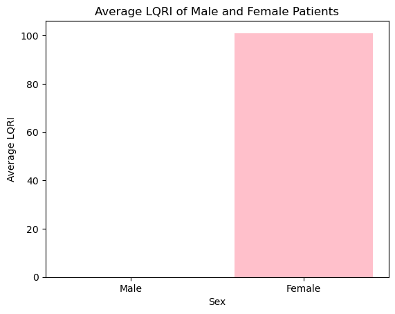

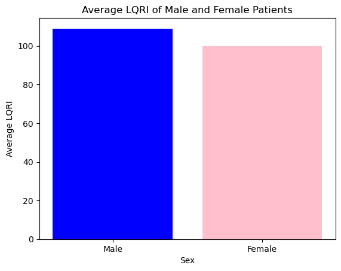

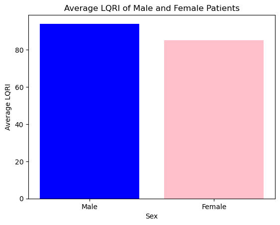

```
6 of 6 tests passed
```

```python
start_testing()

# Examples and tests for main
expect(main('testfile_empty.csv'), None)
#Graph should look like this:
# Average LQRI
#    140|
#       |
#       |
#     0 ---+--+----+--+----- Sex
#         Male    Female
expect(main('testfile_all_zero.csv'), None)
#Graph should look like this:
# Average LQRI
#    140|
#       |
#    60 |
#       |
#       |          lllll
#     0 ---+--+----lllll---- Sex
#         Male    Female
expect(main('testfile_all_MALE.csv'), None)
#Graph should look like this:
# Average LQRI
#    140|
#       | lllll
#    60 | lllll
#       | lllll
#       | lllll
#     0 --lllll------------ Sex
#         Male    Female
expect(main('testfile_all_FEMALE.csv'), None)
#Graph should look like this:
# Average LQRI
#    140|
#       |         llllll
#    60 |         llllll
#       |         llllll
#       |         llllll
#     0 ----------llllll--- Sex
#         Male    Female
expect(main('testfile_all_YES_smoker.csv'), None)
#Graph should look like this:
# Average LQRI
#    140|
#       | lllll   llllll
#    80 | lllll   llllll
#       | lllll   llllll
#       | lllll   llllll
#     0 --lllll---llllll-- Sex
#         Male    Female
expect(main('testfile_all_NO_smoker.csv'), None)
#Graph should look like this:
# Average LQRI
#    140|
#       |
#    80 | lllll   llllll
#       | lllll   llllll
#       | lllll   llllll
#     0 --lllll---llllll-- Sex
#         Male    Female

summary()

start_testing()

# Examples and tests for read
expect (read('testfile_empty.csv'), [])
expect (read('testfile_all_zero.csv'), TEST_ALL_ZERO)
expect (read('testfile_all_MALE.csv'), TEST_ALL_MALE)
expect (read('testfile_all_FEMALE.csv'), TEST_ALL_FEMALE)
expect (read('testfile_all_YES_smoker.csv'), TEST_ALL_YES_SMOKER)
expect (read('testfile_all_NO_smoker.csv'), TEST_ALL_NO_SMOKER)

summary()

start_testing()

# Examples and tests for analyze
expect(analyze(TEST_EMPTY), None)
#Graph should look like this:
# Average LQRI
#    140|
#       |
#       |
#     0 ---+--+----+--+----- Sex
#         Male    Female
expect(analyze(TEST_ALL_ZERO), None)
#Graph should look like this:
# Average LQRI
#    140|
#       |
#    60 |
#       |
#       |          lllll
#     0 ---+--+----lllll---- Sex
#         Male    Female
expect(analyze(TEST_ALL_MALE), None)
#Graph should look like this:
# Average LQRI
#    140|
#       | lllll
#    60 | lllll
#       | lllll
#       | lllll
#     0 --lllll------------ Sex
#         Male    Female
expect(analyze(TEST_ALL_FEMALE), None)
#Graph should look like this:
# Average LQRI
#    140|
#       |         llllll
#    60 |         llllll
#       |         llllll
#       |         llllll
#     0 ----------llllll--- Sex
#         Male    Female
expect(analyze(TEST_ALL_YES_SMOKER), None)
#Graph should look like this:
# Average LQRI
#    140|
#       | lllll   llllll
#    80 | lllll   llllll
#       | lllll   llllll
#       | lllll   llllll
#     0 --lllll---llllll-- Sex
#         Male    Female
expect(analyze(TEST_ALL_NO_SMOKER), None)
#Graph should look like this:
# Average LQRI
#    140|
#       |
#    80 | lllll   llllll
#       | lllll   llllll
#       | lllll   llllll
#     0 --lllll---llllll-- Sex
#         Male    Female

summary()
```

### Final Graph/Chart

Now that everything is working, you **must** call `main` on the intended information source in order to display the final graph/chart:

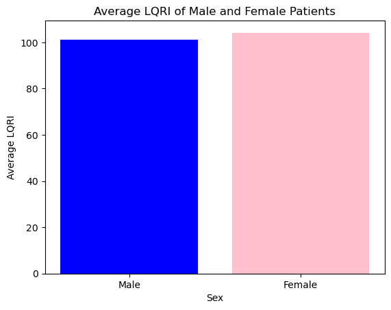

```python
main('medical_insurance_data.csv')
```

```python
# Be sure to select ALL THE FILES YOU NEED (including csv's)
# when you submit. As usual, you cannot edit this cell.
# Instead, run this cell to start the submission process.
from cs103 import submit

COURSE = 147818
ASSIGNMENT = 1966017 # Final submission

submit(COURSE, ASSIGNMENT)

# If your submission fails, SUBMIT by downloading your files and uploading them
# to Canvas. You can learn how on the page "How to submit your Jupyter notebook"
# on our Canvas site.
```

```
Valid(value=True, description='Token')
```

```
SelectMultiple(description='Files', index=(0,), layout=Layout(height='100%', width='50%'), options=('project_f…
```

```
Button(description='submit', icon='check', style=ButtonStyle(), tooltip='submit')
```

# Please double check your submission on Canvas to ensure that the right files (Jupyter file + CSVs) have been submitted and that the files do not contain unexpected errors.

**You should always check your submission on Canvas. It is your responsibility to ensure that the correct file has been submitted for grading.** Regrade or accomodation requests using reasoning such as "I didn't realize I submitted the wrong file"/"I didn't realize the submission didn't work"/"I didn't realize I didn't save before submitting so some of my work is missing" will not be considered.